# Life Satisfaction Analysis between Full-time and Non-Full-time Workers

Wen Yu, Ani Hovhannisyan, Yue He(Joy)

2025-04-21

## Introduction & Methods

This report analyzes the status of life satisfaction among people working full-time and non-full-time in Germany. We test the following Null-Hypothesis: H0: No difference in life satisfaction between Full-time and Non-full-time workers in Germany

We used the variable `mainact` to define employment type. It was recoded into a binary variable `work_type`, where “Paid work” was labeled as “Full-time” and all other types (e.g., Retired, Education, Housework.etc) were grouped as “Not full time”.

```r
library(haven)
library(dplyr)
ess11_de <- read_sav('ESS11-subset.sav') #Please put the data file I uploaded in the whatsapp chat in your 'Sandbox' so that you can import the original data
ess11_clean <- ess11_de %>%
  select(mainact, stflife) %>%
  mutate(stflife=ifelse(stflife==88, NA, stflife))%>%#set the 88 into NA, so that we can delect them in the following code
  filter(!is.na(mainact), !is.na(stflife)) %>% #select the variables that we need and get rid of the empty values
  mutate(mainact=as_factor(mainact)) #convert the mainact into the proper categorical variables with readable value in R
table(ess11_clean$mainact)#check if the data has been cleand successfully
```

```
##
##                                 Paid work
##                                       209
##                                 Education
##                                        37
##               Unemployed, looking for job
##                                         5
##           Unemployed, not looking for job
##                                         1
##              Permanently sick or disabled
##                                        18
##                                   Retired
##                                        89
##             Community or military service
##                                         0
## Housework, looking after children, others
##                                        78
##                                     Other
##                                         3
##                            Not applicable
##                                         0
##                                   Refusal
##                                         0
##                                Don't know
##                                         0
##                                 No answer
##                                         0
```

```r
ess11_analysis <- ess11_clean %>%
  mutate(work_type=ifelse(mainact=='Paid work',
                          'Full-time',
                          'Not full time')) #divide the work_type into two categories: 'Full-time' and 'Not full time' and add an column to the data
```

## Regression Results

According to the linear regression results, the Mean of life satisfaction score for full-time workers was 7.66, while for non-full-time workers it was 7.84. There was no statistically significant difference in life satisfaction between full-time and part-time workers (β = 0.18, p = 0.274 > 0.05). Meanwhile, the 95% CI is between (-0.14,0.50), includes 0. Suggesting that employment type may not be a strong predictor of life satisfaction in this sample. We can’t reject the Null-Hypothesis.

```r
ess11_analysis %>%
  group_by(work_type)%>%
  summarise(main_satisfaction=mean(stflife))
```

```
## # A tibble: 2 × 2
##   work_type     main_satisfaction
##   <chr>                     <dbl>
## 1 Full-time                  7.66
## 2 Not full time              7.84
```

```r
#by the code above, we can see that the mean of main_satisfaction of Full-time is less than that of Not full time
model <- lm(stflife ~ work_type, data = ess11_analysis, na.action=na.omit)
summary(model)#run the regression model, I will send the analysis of this in the whatsapp chat
```

```
##
## Call:
## lm(formula = stflife ~ work_type, data = ess11_analysis, na.action = na.omit)
##
## Residuals:
##     Min      1Q  Median      3Q     Max
## -6.8355 -0.8355  0.3445  1.1645  2.3445
##
## Coefficients:
##                        Estimate Std. Error t value Pr(>|t|)
## (Intercept)              7.6555     0.1190  64.317   <2e-16 ***
## work_typeNot full time   0.1800     0.1643   1.096    0.274
## ---
## Signif. codes:  0 '***' 0.001 '**' 0.01 '*' 0.05 '.' 0.1 ' ' 1
##
## Residual standard error: 1.721 on 438 degrees of freedom
## Multiple R-squared:  0.002733,   Adjusted R-squared:  0.0004566
## F-statistic: 1.201 on 1 and 438 DF,  p-value: 0.2738
```

## Boxplot

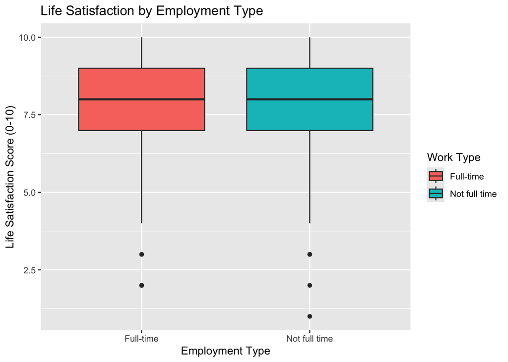

```r
library(ggplot2)
library(tidyverse)
# draw a boxplot
ggplot(ess11_analysis,
       aes(x = work_type,
           y = stflife,
           fill = work_type)) +
  geom_boxplot() +
  labs(
    title = "Life Satisfaction by Employment Type",
    x = "Employment Type",
    y = "Life Satisfaction Score (0-10)",
    fill = "Work Type"
  )
```

```r
# dir.create("data_clean", showWarnings = FALSE)
# write_rds(ess11_analysis, "data_clean/ess11_analysis.rds")
```

## Members & Contributions

Wen Yu: Data Import, Cleaning & Regression Analysis  
Yue He(Joy): Visualization (Boxplot), Report Writing  
Ani Hovhannisyan: GitHub Repository Setup, README, Integration